# Electron cutout factor model report

This model allows for the prediction of electron cut-out factors from previously measured cutouts. Input data is retrieved from csv files saved at `input/data/*.csv`. These measured cutout factors are then modelled using a smoothing spline. A region is defined which is considered to have sufficent cutout data for prediction. Over this valid region the provided data is used to predict an overall uncertainty for prediction. Finally the results are output to user friendly csv files.

This is a print out of the code that was run in order to produce the outputs given within this directory.

### Code Overview

The code is broken up into three major sections, code initialisation, primary computations, and finally output data to files. Below is an overview of these sections.

#### Code initialisation

- Required packages | Loading of the required python packages
  - Loading packages
  - Package options
- User parameters | Importing the user parameters from `/input/parameters.csv`
  - Load
  - Display
- Input output paths and directories | Defining the locations where files are loaded from and saved to
  - Input
  - Output

#### Primary computations

- The cutout data |
  - Load data
  - Table of the received data
  - Figure of the received data
- Creating the fit |
  - Spline
  - Mirrored form
  - Width and aspect ratio form
- Valid region definitions |
  - Angle gap
  - Fit give
- Residuals |
  - Residuals standard deviation
  - Residuals histogram
  - Residuals scatter plot
  - Residuals table
- Prediction uncertainty |
  - Remove and recalculate fit
  - User defined thresholds
  - Prediction differences table
  - Standard deviation of valid prediction differences
  - Histogram of valid prediction differences

#### Output data to files

- Interpolation table |
  - User defined grid size
  - Creating the interpolation mesh
  - Save interploation table to csv
- Requested cutout factors |
  - File used
  - Loading the requested cutouts
  - Calculating the requested factors
  - Save requested factor outputs to csv

## Code initialisation

### Required packages

Loading of the required python packages

#### Loading packages

```python
# Imports numpy and matplotlib
# Libraries similar to MATLAB / Octave
%pylab inline

# For naming files
import datetime

# For directory and file control
import os

# To find list of csv files
from glob import glob

# To read csv files
import csv

# For the displaying, loading, and saving of tables
import pandas as pd

# To display panda tables as html
from IPython.core.display import display_html

# The interpolation method employed by this model
from scipy.interpolate import SmoothBivariateSpline

# Enables 3D plots within matplotlib
from mpl_toolkits.mplot3d import Axes3D

# Imports the give and gap threshold functions contained within threshold_functions.py
from threshold_functions import *
```

Back to top

#### Package options

```python
# Makes the panda tables display no more than 12 columns
# The html output bugs out without this
pd.options.display.max_columns = 12

# Makes all figures have a higher resolution
# Figures were too small without this
pylab.rcParams['savefig.dpi'] = 150
```

Back to top

### User parameters

Importing the user parameters from `/input/parameters.csv`

#### Load

```python
# The file path of the paramters.csv file
parameterFilepath = "../input/parameters.csv"

# Loads the parameters.csv file
reader = csv.reader(open(parameterFilepath),delimiter=',')

# Create a dictionary where the keys are the first column of the csv
# and the values are the corresponding second column
parameters = dict(([x[0],float(x[1])] for x in reader))
```

Back to top

#### Display

```python
# Outputs the contents of the dictionary `parameters`
parameters
```

```
{'widthInterpResolution': 20.0,
 'ratioInterpResolution': 20.0,
 'gapThreshold': 130.0,
 'giveThreshold': 0.2,
 'figureAzim': -140.0,
 'figureElev': 30.0}
```

Back to top

### Input output paths and directories

Defining the locations where files are loaded from and saved to

#### Input

```python
# If this notebook was produced as expected using the `runmodel.py` script
# then the input filepath is stored in the processes environmental variable
inputDataFilepath = os.environ.get('INPUTDATAFILEPATH', -1)

# If this notebook was not produced in the expected manner a dummy filepath is used
# This will print a warning
if inputDataFilepath == -1:
    inputDataFilelist = glob("../input/data/*.csv")
    inputDataFilepath = inputDataFilelist[0]

    print("Warning: input filepath was not retrievable")

# Store the base filename that has been used to run this script
inputDataFilename = os.path.basename(inputDataFilepath)[0:-4]
```

```python
# Display the input file path
inputDataFilepath
```

```
'../input/data\\10app09eng.csv'
```

Back to top

#### Output

```python
# If this notebook was produced as expected using the `runmodel.py` script
# then the model output directory is stored in the processes environmental variable
modelOutputDirectory = os.environ.get('MODELOUTPUTDIRECTORY', -1)

# If this notebook was not produced in the expected manner a dummy directory is used
# This will print a warning
if modelOutputDirectory == -1:
    stamp = datetime.datetime.now().strftime("%Y%m%d_%H%M%S")
    inputDataFilename = os.path.basename(inputDataFilepath)[0:-4]
    modelOutputDirectory = "../output/"+stamp+"/"+inputDataFilename

    print("Warning: model output directory was not retrievable")

# Creates the required directory if it does not already exist
if not os.path.exists(modelOutputDirectory):
    os.makedirs(modelOutputDirectory)
```

```python
# Display the model output directory
modelOutputDirectory
```

```
'../output/20140807_173714/10app09eng'
```

Back to top

## Primary computations

### The cutout data

#### Load data

```python
# Use pandas to load the csv file
cutoutData = pd.read_csv(inputDataFilepath)

# Define width, length, and factor as the csv columns
# which had that corresponding header
width = cutoutData['width'].values
length = cutoutData['length'].values
factor = cutoutData['factor'].values

# Swap width and length values if order was mistaken
swap = width > length

store = width[swap]
width[swap] = length[swap]
length[swap] = store

# Define the cutout aspect ratio
ratio = width/length
```

Back to top

#### Table of the received data

```python
# Create a pandas table using the width, length, and factor variables
# for the purpose of display
df = pd.DataFrame(transpose([width, length, factor]))

# Label the columns
df.columns = ['width', 'length', 'factor']

# Display the table in html format
display_html(df)
```

|  | width | length | factor |
| --- | --- | --- | --- |
| 0 | 2.90 | 6.50 | 0.953 |
| 1 | 3.40 | 7.50 | 0.973 |
| 2 | 3.50 | 7.60 | 0.978 |
| 3 | 4.00 | 7.60 | 0.993 |
| 4 | 4.15 | 6.80 | 0.987 |
| 5 | 4.30 | 8.30 | 0.993 |
| 6 | 4.60 | 6.40 | 0.994 |
| 7 | 5.25 | 5.90 | 0.993 |
| 8 | 5.30 | 10.95 | 1.006 |
| 9 | 5.50 | 6.00 | 1.001 |
| 10 | 5.50 | 8.25 | 1.002 |
| 11 | 5.50 | 9.50 | 1.004 |
| 12 | 5.70 | 6.00 | 1.004 |
| 13 | 6.00 | 7.50 | 1.008 |
| 14 | 6.10 | 8.50 | 1.007 |
| 15 | 6.35 | 10.20 | 1.007 |
| 16 | 6.90 | 7.10 | 1.009 |
| 17 | 7.00 | 9.50 | 1.008 |
| 18 | 7.00 | 10.40 | 1.008 |
| 19 | 7.05 | 9.05 | 1.010 |
| 20 | 7.55 | 10.05 | 1.010 |
| 21 | 8.00 | 9.60 | 1.008 |
| 22 | 8.40 | 9.30 | 1.007 |

Back to top

#### Figure of the received data

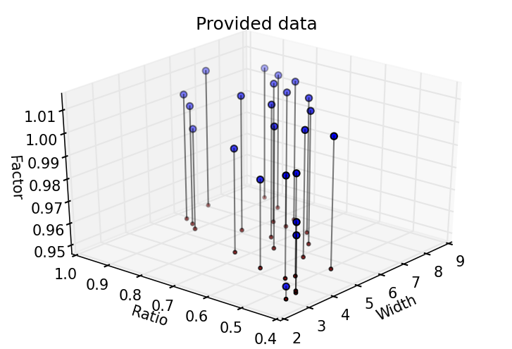

```python
# Create a figure object
fig = plt.figure()

# Add a 3D axis
ax = fig.add_subplot(111, projection='3d')

# Calculate the z axis limits
bot = np.amin(factor) - 0.1 * np.ptp(factor)
top = np.amax(factor) + 0.1 * np.ptp(factor)

# Create a red scatter plot on the bottom plane of the figure
# for visual reference
ax.scatter(width,ratio,bot,c='r',s=5)

# Draw black lines connecting each data point and the bottom plane
# for visual reference
for i in range(len(factor)):
    ax.plot([width[i],width[i]],[ratio[i],ratio[i]],[factor[i],bot],'k',alpha=0.5)

# Scatter plot the 3D data that has been provided
ax.scatter(width,ratio,factor,c='b')

# Define the figure labels
ax.set_xlabel('Width')
ax.set_ylabel('Ratio')
ax.set_zlabel('Factor')

# Define the figure title
ax.set_title('Provided data')

# Enforce the z axis limits previously calculated
ax.set_zlim(bot,top)

# Adjust the viewing angle of the figure to that requested in `parameters.csv`
ax.view_init(elev=parameters['figureElev'], azim=parameters['figureAzim'])
```

Back to top

### Creating the fit

#### Spline

Mirror the data for spline fitting. This is done so that the full information available is used for the spline fitting around shapes with aspect ratios close to unity.

```python
# Duplicate the width data
widthMirrored = np.append(width,width)

# Mirror the ratio data and take the base 2 log
ratioLogMirrored = np.log2(np.append(width/length,length/width))

# Duplicate the factor data
factorMirrored = np.append(factor,factor)
```

Impliment the spline fit

```python
# Compute the smoothed bivariate spline using the mirrored data
splineFit = SmoothBivariateSpline(widthMirrored,ratioLogMirrored,factorMirrored)
```

Back to top

#### Mirrored form

```python
xVec1 = linspace(widthMirrored.min(),widthMirrored.max(),100)
yVec1 = linspace(ratioLogMirrored.min(),ratioLogMirrored.max(),100)

xMesh1, yMesh1 = meshgrid(xVec1, yVec1)
gapMesh1 = angle_gap(xMesh1,yMesh1,widthMirrored,ratioLogMirrored,1,2)
giveMesh1 = fit_give(xMesh1,yMesh1,widthMirrored,ratioLogMirrored,factorMirrored)

zMesh1 = splineFit.ev(xMesh1, yMesh1)

ref1 = (gapMesh1>parameters['gapThreshold']) | (giveMesh1>parameters['giveThreshold'])
zMesh1[ref1] = nan
```

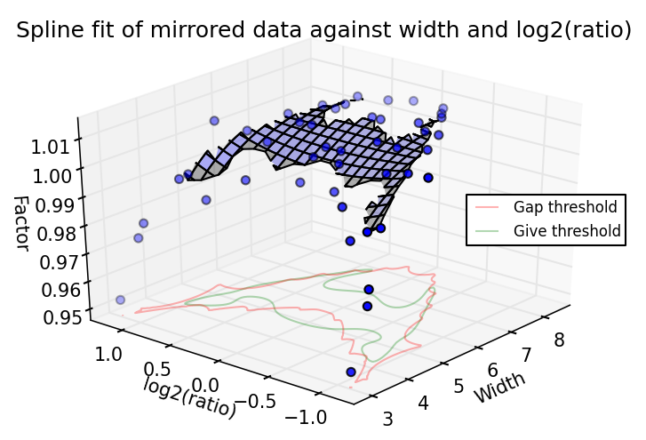

```python
fig = plt.figure()
ax = fig.add_subplot(111, projection='3d')


ax.contour(xMesh1,yMesh1,gapMesh1, offset=bot, levels=[parameters['gapThreshold']], colors='r',alpha=0.3)
ax.contour(xMesh1,yMesh1,giveMesh1, offset=bot, levels=[parameters['giveThreshold']], colors='g',alpha=0.3)

proxyGap, = ax.plot([width.min(),width.min()],[ratioLogMirrored.min(),ratioLogMirrored.min()],[bot,bot],'r-',alpha=0.3)
proxyGive, = ax.plot([width.min(),width.min()],[ratioLogMirrored.min(),ratioLogMirrored.min()],[bot,bot],'g-',alpha=0.3)


ax.plot_surface(xMesh1,yMesh1,zMesh1,alpha=0.3,rstride=4,cstride=4)

ax.scatter(widthMirrored,ratioLogMirrored,factorMirrored,'b')
ax.set_xlabel('Width')
ax.set_ylabel('log2(ratio)')
ax.set_zlabel('Factor')

ax.set_title('Spline fit of mirrored data against width and log2(ratio)')

ax.view_init(elev=parameters['figureElev'], azim=parameters['figureAzim'])

ax.set_zlim(bot,top)

legend([proxyGap,proxyGive],['Gap threshold', 'Give threshold'],loc=7,prop={'size':8})
```

Back to top

#### Width and aspect ratio form

```python
xVec2 = linspace(width.min(),width.max(),100)
yVec2 = linspace(ratio.min(),ratio.max(),100)

xMesh2, yMesh2 = meshgrid(xVec2, yVec2)
gapMesh2 = angle_gap(xMesh2,log2(yMesh2),widthMirrored,ratioLogMirrored,1,2)
giveMesh2 = fit_give(xMesh2,log2(yMesh2),widthMirrored,ratioLogMirrored,factorMirrored)

zMesh2 = splineFit.ev(xMesh2, log2(yMesh2))

ref2 = (gapMesh2>parameters['gapThreshold']) | (giveMesh2>parameters['giveThreshold'])
zMesh2[ref2] = nan
```

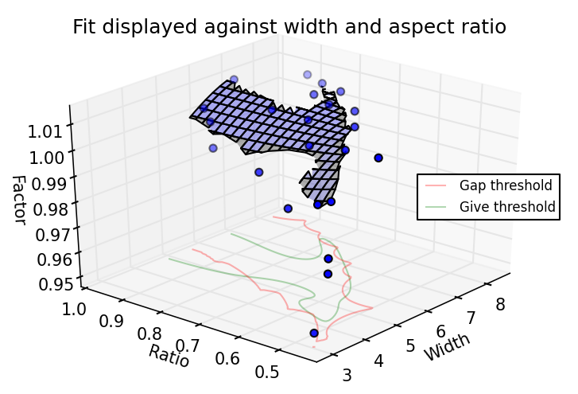

```python
fig = plt.figure()
ax = fig.add_subplot(111, projection='3d')

ax.contour(xMesh2,yMesh2,gapMesh2, offset=bot, levels=[parameters['gapThreshold']], colors='r',alpha=0.3)
ax.contour(xMesh2,yMesh2,giveMesh2, offset=bot, levels=[parameters['giveThreshold']], colors='g',alpha=0.3)

proxyGap, = ax.plot([width.min(),width.min()],[ratio.min(),ratio.min()],[bot,bot],'r-',alpha=0.3)
proxyGive, = ax.plot([width.min(),width.min()],[ratio.min(),ratio.min()],[bot,bot],'g-',alpha=0.3)

ax.plot_surface(xMesh2,yMesh2,zMesh2,alpha=0.3,rstride=4,cstride=4)

sc = ax.scatter(width,ratio,factor)

ax.set_xlabel('Width')
ax.set_ylabel('Ratio')
ax.set_zlabel('Factor')

ax.set_ylim(top = 1)

ax.set_title('Fit displayed against width and aspect ratio')

ax.view_init(elev=parameters['figureElev'], azim=parameters['figureAzim'])

ax.set_zlim(bot,top)

legend([proxyGap,proxyGive],['Gap threshold', 'Give threshold'],loc=7,prop={'size':8})
```

Back to top

### Valid region definitions

#### Angle gap

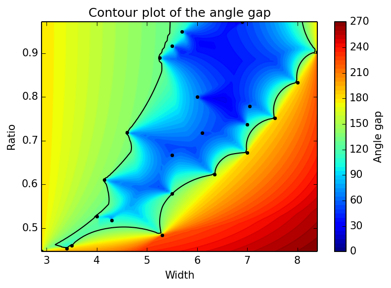

```python
fig = plt.figure()
ax = fig.add_subplot(111)

cf = ax.contourf(xMesh2,yMesh2,gapMesh2,60)
colorbar(cf, label='Angle gap')

ax.contour(xMesh2,yMesh2,gapMesh2,60)

ax.contour(xMesh2,yMesh2,gapMesh2,levels=[parameters['gapThreshold']],colors='k')

ax.plot(width,ratio,'k.')

ax.set_xlabel('Width')
ax.set_ylabel('Ratio')

ax.set_title('Contour plot of the angle gap')
```

Back to top

#### Fit give

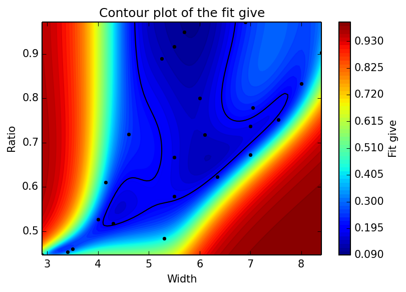

```python
fig = plt.figure()
ax = fig.add_subplot(111)

cf = ax.contourf(xMesh2,yMesh2,giveMesh2,60)
colorbar(cf, label='Fit give')

ax.contour(xMesh2,yMesh2,giveMesh2,60)

ax.contour(xMesh2,yMesh2,giveMesh2,levels=[parameters['giveThreshold']],colors='k')

ax.plot(width,ratio,'k.')

ax.set_xlabel('Width')
ax.set_ylabel('Ratio')

ax.set_title('Contour plot of the fit give')
```

Back to top

### Residuals

#### Residuals standard deviation

```python
fitFactors = splineFit.ev(width,log2(ratio))
residuals = fitFactors - factor

std(residuals)
```

```
0.0017299293669489758
```

Back to top

#### Residuals histogram

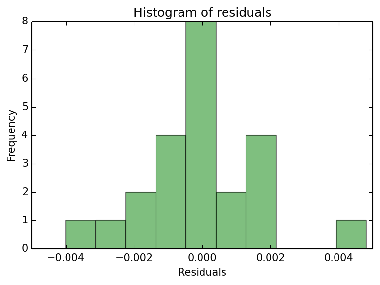

```python
fig = plt.figure()
ax = fig.add_subplot(111)

n, bins, patches = hist(residuals)
setp(patches, 'facecolor', 'g', 'alpha', 0.5)

ax.set_xlabel('Residuals')
ax.set_ylabel('Frequency')

ax.set_title('Histogram of residuals')
```

Back to top

#### Residuals scatter plot

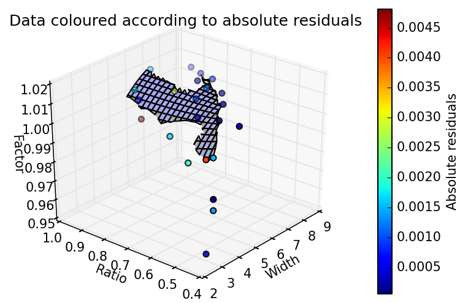

```python
fig = plt.figure()
ax = fig.add_subplot(111, projection='3d')

ax.plot_surface(xMesh2,yMesh2,zMesh2,alpha=0.3,rstride=4,cstride=4)

sc = ax.scatter(width,ratio,factor,c=abs(residuals))
fig.colorbar(sc, label='Absolute residuals')

ax.set_xlabel('Width')
ax.set_ylabel('Ratio')
ax.set_zlabel('Factor')

ax.set_title('Data coloured according to absolute residuals')

ax.view_init(elev=parameters['figureElev'], azim=parameters['figureAzim'])
```

Back to top

#### Residuals table

```python
df = pd.DataFrame(transpose([width, length, factor, fitFactors, residuals, residuals/std(residuals)]))
df.columns = ['Width', 'Length', 'Measured Factor', 'Fit Factor', 'Residual', 'Standard deviations']
display_html(df)
```

|  | Width | Length | Measured Factor | Fit Factor | Residual | Standard deviations |
| --- | --- | --- | --- | --- | --- | --- |
| 0 | 2.90 | 6.50 | 0.953 | 0.952660 | -0.000340 | -0.196498 |
| 1 | 3.40 | 7.50 | 0.973 | 0.974382 | 0.001382 | 0.798993 |
| 2 | 3.50 | 7.60 | 0.978 | 0.977853 | -0.000147 | -0.085016 |
| 3 | 4.00 | 7.60 | 0.993 | 0.988992 | -0.004008 | -2.316698 |
| 4 | 4.15 | 6.80 | 0.987 | 0.988939 | 0.001939 | 1.120584 |
| 5 | 4.30 | 8.30 | 0.993 | 0.994593 | 0.001593 | 0.920855 |
| 6 | 4.60 | 6.40 | 0.994 | 0.992349 | -0.001651 | -0.954488 |
| 7 | 5.25 | 5.90 | 0.993 | 0.997812 | 0.004812 | 2.781517 |
| 8 | 5.30 | 10.95 | 1.006 | 1.006355 | 0.000355 | 0.205094 |
| 9 | 5.50 | 6.00 | 1.001 | 1.000333 | -0.000667 | -0.385462 |
| 10 | 5.50 | 8.25 | 1.002 | 1.002340 | 0.000340 | 0.196265 |
| 11 | 5.50 | 9.50 | 1.004 | 1.004058 | 0.000058 | 0.033374 |
| 12 | 5.70 | 6.00 | 1.004 | 1.002250 | -0.001750 | -1.011886 |
| 13 | 6.00 | 7.50 | 1.008 | 1.005131 | -0.002869 | -1.658596 |
| 14 | 6.10 | 8.50 | 1.007 | 1.005960 | -0.001040 | -0.601050 |
| 15 | 6.35 | 10.20 | 1.007 | 1.006845 | -0.000155 | -0.089693 |
| 16 | 6.90 | 7.10 | 1.009 | 1.010492 | 0.001492 | 0.862641 |
| 17 | 7.00 | 9.50 | 1.008 | 1.009258 | 0.001258 | 0.727266 |
| 18 | 7.00 | 10.40 | 1.008 | 1.008193 | 0.000193 | 0.111308 |
| 19 | 7.05 | 9.05 | 1.010 | 1.009852 | -0.000148 | -0.085489 |
| 20 | 7.55 | 10.05 | 1.010 | 1.009168 | -0.000832 | -0.481129 |
| 21 | 8.00 | 9.60 | 1.008 | 1.008755 | 0.000755 | 0.436536 |
| 22 | 8.40 | 9.30 | 1.007 | 1.006432 | -0.000568 | -0.328429 |

Back to top

### Prediction uncertainty

Prediction uncertainty tests are achieved by removing the data points in question, creating a new fit without that particular data point, and then comparing the newly predicted value to the provided measured value.

#### Remove and recalculate fit

```python
predictedFactor = zeros(shape(width))

predictionAngleGap = zeros(shape(width))
predictionFitGive = zeros(shape(width))
#predictionFlexibility = zeros(shape(width))

for i in range(len(width)):

    x = width[i]
    y = log2(width[i]/length[i])

    adjWidth = np.delete(width,i)
    adjLength = np.delete(length,i)
    adjFactor = np.delete(factor,i)

    adjWidthMirrored = np.append(adjWidth,adjWidth)
    adjRatioLogMirrored = np.log2(np.append(adjWidth/adjLength,adjLength/adjWidth))
    adjFactorMirrored = np.append(adjFactor,adjFactor)

    adjSplineFit = SmoothBivariateSpline(adjWidthMirrored,adjRatioLogMirrored,adjFactorMirrored)

    predictedFactor[i] = adjSplineFit.ev(x,y)
    predictionAngleGap[i] = angle_gap(x,y,adjWidthMirrored,adjRatioLogMirrored,1,2)
    predictionFitGive[i] = fit_give(x,y,adjWidthMirrored,adjRatioLogMirrored,adjFactorMirrored)
```

Back to top

#### User defined thresholds

In order for a data point to be able to be predicted it needs to be within these user defined tolerances:

```python
df = pd.DataFrame([parameters['gapThreshold'], parameters['giveThreshold']])
df.index = ['Gap', 'Give']
df.columns = ['Threshold']
display_html(df)
```

|  | Threshold |
| --- | --- |
| Gap | 130.0 |
| Give | 0.2 |

Back to top

#### Prediction differences table

The prediction of each of the measured data points is given below. Those with an angle gap or fit give higher than the tolerances given above would normally give a result of "nan".

```python
difference = factor - predictedFactor
withinThresholds = (predictionAngleGap<parameters['gapThreshold']) & (predictionFitGive<parameters['giveThreshold'])

df = pd.DataFrame(transpose([width, length, factor, predictedFactor, difference,
                             predictionAngleGap, predictionFitGive, withinThresholds]))
df.columns = ['Width', 'Length', 'Measured Factor', 'Predicted Factor', 'Difference',
              'Angle Gap', 'Fit Give', 'Within thresholds']
display_html(df)
```

|  | Width | Length | Measured Factor | Predicted Factor | Difference | Angle Gap | Fit Give | Within thresholds |
| --- | --- | --- | --- | --- | --- | --- | --- | --- |
| 0 | 2.90 | 6.50 | 0.953 | 0.973784 | -0.020784 | 284.242157 | 0.955033 | 0 |
| 1 | 3.40 | 7.50 | 0.973 | 0.975333 | -0.002333 | 180.944664 | 0.454101 | 0 |
| 2 | 3.50 | 7.60 | 0.978 | 0.977765 | 0.000235 | 143.656317 | 0.394426 | 0 |
| 3 | 4.00 | 7.60 | 0.993 | 0.987571 | 0.005429 | 129.313106 | 0.324809 | 0 |
| 4 | 4.15 | 6.80 | 0.987 | 0.991114 | -0.004114 | 141.624306 | 0.533067 | 0 |
| 5 | 4.30 | 8.30 | 0.993 | 0.995073 | -0.002073 | 109.834028 | 0.234138 | 0 |
| 6 | 4.60 | 6.40 | 0.994 | 0.991497 | 0.002503 | 140.012182 | 0.339913 | 0 |
| 7 | 5.25 | 5.90 | 0.993 | 0.999498 | -0.006498 | 132.987287 | 0.174532 | 0 |
| 8 | 5.30 | 10.95 | 1.006 | 1.006906 | -0.000906 | 219.670989 | 0.774959 | 0 |
| 9 | 5.50 | 6.00 | 1.001 | 1.000129 | 0.000871 | 105.895835 | 0.145704 | 1 |
| 10 | 5.50 | 8.25 | 1.002 | 1.002389 | -0.000389 | 61.236829 | 0.223333 | 0 |
| 11 | 5.50 | 9.50 | 1.004 | 1.004073 | -0.000073 | 129.511904 | 0.235755 | 0 |
| 12 | 5.70 | 6.00 | 1.004 | 1.001751 | 0.002249 | 109.157829 | 0.129344 | 1 |
| 13 | 6.00 | 7.50 | 1.008 | 1.004614 | 0.003386 | 71.570398 | 0.174184 | 1 |
| 14 | 6.10 | 8.50 | 1.007 | 1.005837 | 0.001163 | 59.486232 | 0.182652 | 1 |
| 15 | 6.35 | 10.20 | 1.007 | 1.006794 | 0.000206 | 160.761430 | 0.305188 | 0 |
| 16 | 6.90 | 7.10 | 1.009 | 1.012757 | -0.003757 | 49.031526 | 0.433839 | 0 |
| 17 | 7.00 | 9.50 | 1.008 | 1.009505 | -0.001505 | 103.486593 | 0.222317 | 0 |
| 18 | 7.00 | 10.40 | 1.008 | 1.008327 | -0.000327 | 180.809163 | 0.475043 | 0 |
| 19 | 7.05 | 9.05 | 1.010 | 1.009811 | 0.000189 | 66.558003 | 0.304590 | 0 |
| 20 | 7.55 | 10.05 | 1.010 | 1.008795 | 0.001205 | 182.202350 | 0.296213 | 0 |
| 21 | 8.00 | 9.60 | 1.008 | 1.009034 | -0.001034 | 176.402598 | 0.344525 | 0 |
| 22 | 8.40 | 9.30 | 1.007 | 1.008325 | -0.001325 | 228.694058 | 0.692007 | 0 |

Back to top

#### Standard deviation of valid prediction differences

The standard deviation of the prediction differences for valid data points is given as the following:

```python
print("There are", sum(withinThresholds), "points within give and gap thresholds."+
      "\nThe standard deviation of the prediction differences for these is", std(difference[withinThresholds]))
```

```
There are 4 points within give and gap thresholds.
The standard deviation of the prediction differences for these is 0.00099130748091
```

Back to top

#### Histogram of valid prediction differences

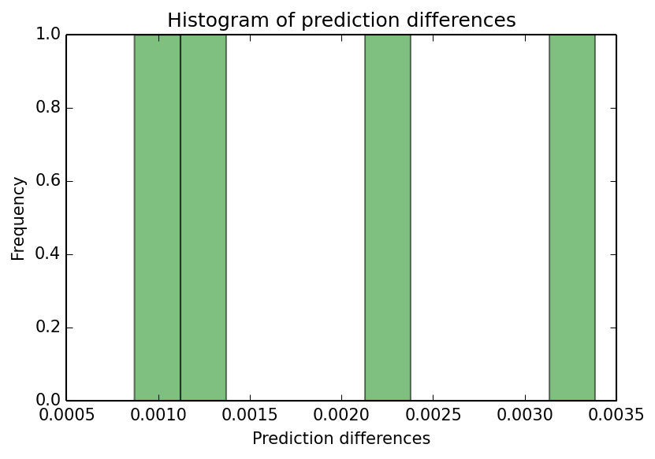

```python
fig = plt.figure()
ax = fig.add_subplot(111)

n, bins, patches = hist(difference[withinThresholds])
setp(patches, 'facecolor', 'g', 'alpha', 0.5)

ax.set_xlabel('Prediction differences')
ax.set_ylabel('Frequency')

ax.set_title('Histogram of prediction differences')
```

Back to top

## Output data to files

### Interpolation table

#### User defined grid size

```python
df = pd.DataFrame([parameters['widthInterpResolution'], parameters['ratioInterpResolution']])
df.index = ['Width', 'Ratio']
df.columns = ['Resolutions']
display_html(df)
```

|  | Resolutions |
| --- | --- |
| Width | 20 |
| Ratio | 20 |

Back to top

#### Creating the interpolation mesh

```python
# ===========================
#            IDEA
#
# This mesh can be more intelligently created.
# Spread out the steps so that on average each column/row jump has similar cutout effect.
# Could even make it so that the user input is instead, "diff between rows and cols".
#  ^^ This way should work. Use iterative optimisation:
#     maybe scipy.optimize.minimize of
#     `mean((max(columnDiffs) - parameterDiff)**2) + mean((max(rowDiffs) - parameterDiff)**2)`
# ===========================

xVec3 = around(linspace(width.min(),width.max(),parameters['widthInterpResolution']),decimals = 3)
yVec3 = around(linspace(ratio.min(),ratio.max(),parameters['ratioInterpResolution']),decimals = 3)

xMesh3, yMesh3 = meshgrid(xVec3, yVec3)
gapMesh3 = angle_gap(xMesh3,log2(yMesh3),widthMirrored,ratioLogMirrored,1,2)
giveMesh3 = fit_give(xMesh3,log2(yMesh3),widthMirrored,ratioLogMirrored,factorMirrored)

zMesh3 = splineFit.ev(xMesh3, log2(yMesh3))

ref3 = (gapMesh3>parameters['gapThreshold']) | (giveMesh3>parameters['giveThreshold'])
zMesh3[ref3] = nan

interpDf = pd.DataFrame(zMesh3)
interpDf.columns = xVec3
interpDf.columns.name = 'width'
interpDf.index = yVec3
interpDf.index.name = 'ratio'


display_html(interpDf)
```

| width ratio | 2.9 | 3.189 | 3.479 | 3.768 | 4.058 | 4.347 | ... | 6.953 | 7.242 | 7.532 | 7.821 | 8.111 | 8.4 |
| --- | --- | --- | --- | --- | --- | --- | --- | --- | --- | --- | --- | --- | --- |
| 0.446 | NaN | NaN | NaN | NaN | NaN | NaN | ... | NaN | NaN | NaN | NaN | NaN | NaN |
| 0.474 | NaN | NaN | NaN | NaN | NaN | NaN | ... | NaN | NaN | NaN | NaN | NaN | NaN |
| 0.501 | NaN | NaN | NaN | NaN | NaN | NaN | ... | NaN | NaN | NaN | NaN | NaN | NaN |
| 0.529 | NaN | NaN | NaN | NaN | NaN | 0.994815 | ... | NaN | NaN | NaN | NaN | NaN | NaN |
| 0.557 | NaN | NaN | NaN | NaN | NaN | 0.993630 | ... | NaN | NaN | NaN | NaN | NaN | NaN |
| 0.584 | NaN | NaN | NaN | NaN | NaN | 0.992630 | ... | NaN | NaN | NaN | NaN | NaN | NaN |
| 0.612 | NaN | NaN | NaN | NaN | NaN | NaN | ... | NaN | NaN | NaN | NaN | NaN | NaN |
| 0.640 | NaN | NaN | NaN | NaN | NaN | NaN | ... | NaN | NaN | NaN | NaN | NaN | NaN |
| 0.667 | NaN | NaN | NaN | NaN | NaN | NaN | ... | NaN | NaN | NaN | NaN | NaN | NaN |
| 0.695 | NaN | NaN | NaN | NaN | NaN | NaN | ... | 1.008578 | NaN | NaN | NaN | NaN | NaN |
| 0.723 | NaN | NaN | NaN | NaN | NaN | NaN | ... | 1.009010 | NaN | NaN | NaN | NaN | NaN |
| 0.750 | NaN | NaN | NaN | NaN | NaN | NaN | ... | 1.009367 | 1.009557 | NaN | NaN | NaN | NaN |
| 0.778 | NaN | NaN | NaN | NaN | NaN | NaN | ... | NaN | NaN | NaN | NaN | NaN | NaN |
| 0.806 | NaN | NaN | NaN | NaN | NaN | NaN | ... | NaN | NaN | NaN | NaN | NaN | NaN |
| 0.833 | NaN | NaN | NaN | NaN | NaN | NaN | ... | NaN | NaN | NaN | NaN | NaN | NaN |
| 0.861 | NaN | NaN | NaN | NaN | NaN | NaN | ... | NaN | NaN | NaN | NaN | NaN | NaN |
| 0.889 | NaN | NaN | NaN | NaN | NaN | NaN | ... | NaN | NaN | NaN | NaN | NaN | NaN |
| 0.916 | NaN | NaN | NaN | NaN | NaN | NaN | ... | NaN | NaN | NaN | NaN | NaN | NaN |
| 0.944 | NaN | NaN | NaN | NaN | NaN | NaN | ... | NaN | NaN | NaN | NaN | NaN | NaN |
| 0.972 | NaN | NaN | NaN | NaN | NaN | NaN | ... | NaN | NaN | NaN | NaN | NaN | NaN |

20 rows × 20 columns

Back to top

#### Save interpolation table to csv

```python
interpolationTableFilepath = modelOutputDirectory+"/interpolation-table.csv"

interpDf.to_csv(interpolationTableFilepath, index_label = 'ratio | width')
```

Back to top

### Requested cutout factors

#### File used

```python
requestedCutoutFilepath = '../input/requested-cutouts/'+inputDataFilename+'.csv'

if os.path.isfile(requestedCutoutFilepath):
    print("File found at '"+requestedCutoutFilepath+"'")
else:
    print("No requested cutout file found for "+inputDataFilename+
          "\nLooked for '"+requestedCutoutFilepath+"'")
```

```
No requested cutout file found for 10app09eng
Looked for '../input/requested-cutouts/10app09eng.csv'
```

Back to top

#### Loading the requested cutouts

```python
if os.path.isfile(requestedCutoutFilepath):

    requestedCutouts = pd.read_csv(requestedCutoutFilepath)
    reqWidth = requestedCutouts['width'].values
    reqLength = requestedCutouts['length'].values

    display_html(requestedCutouts)
```

Back to top

#### Calculating the requested factors

```python
if os.path.isfile(requestedCutoutFilepath):

    x = reqWidth
    y = log2(reqWidth/reqLength)

    predictedCutouts = splineFit.ev(x,y)

    predictionGap = angle_gap(x,y,widthMirrored,ratioLogMirrored,1,2)
    predictionGive = fit_give(x,y,widthMirrored,ratioLogMirrored,factorMirrored)

    ref4 = (predictionGap>parameters['gapThreshold']) | (predictionGive>parameters['giveThreshold'])
    predictedCutouts[ref4] = nan

    predictedDf = pd.DataFrame(transpose([reqWidth, reqLength, predictionGap, predictionGive, predictedCutouts]))
    predictedDf.columns = ['width', 'length', 'gap', 'give','factor']
    display_html(predictedDf)
```

Back to top

#### Save requested factor outputs to csv

```python
if os.path.isfile(requestedCutoutFilepath):

    predictedCutoutsFilepath = modelOutputDirectory+"/predicted-cutouts.csv"

    predictedDf.to_csv(path_or_buf = predictedCutoutsFilepath, index=False)
```

Back to top